# Using ozonesondes to observe the Antarctic ozone hole

A reproducible data analysis project

Author

Jackson Vanfleet-Brown

Published

September 24, 2024

## Introduction

The **ozone layer** is a component of our atmosphere shielding the surface of our planet from harmful ultraviolet radiation. Due to chemicals called *CFCs* being released in the atmosphere, we began to observe a global weakening of the ozone layer which posed a radical threat to public health.

Over the course of just a few decades, ozone depletion had become so severe it began causing the **Antarctic ozone hole,** a region in which the ozone layer was utterly destroyed for several months of the year. The phenomenon was fortunately limited to the spring in Anarctica – but it represented what was bound to occur everywhere throughout the entire year. This helped spark the international movement to ban these chemicals and reverse the destruction of the ozone layer.

Amundsen-Scott South Pole Station is used as a launch site for for instruments called **ozonesondes** which measure ozone concentrations at various altitudes in the atmosphere. From the **vertical ozone profiles** that they return, we observe the formation and subsequent closure of the Antarctic ozone hole each year.

## Objective

Use ozonesonde vertical profiles to recreate Figure 1, depicting a cross section of the atmosphere over South Pole Station over the course of a year.

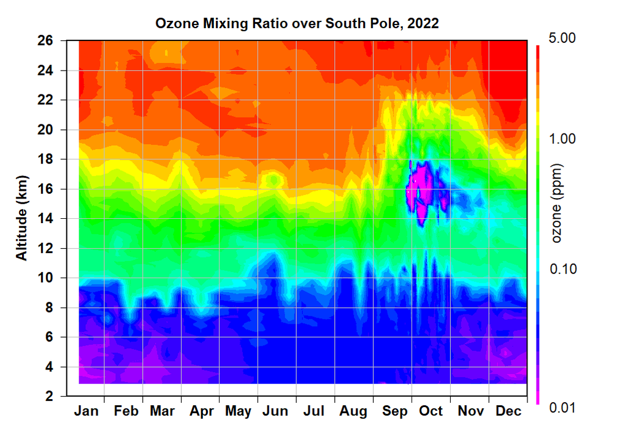

## Methods

I elected to use **nearest neighbors** to estimate ozone concentration as explained by year, Julian date, and altitude. This model was necessary because, as shown in Figure 2, ozonesonde observations alone were too dispersed to meet the objective.

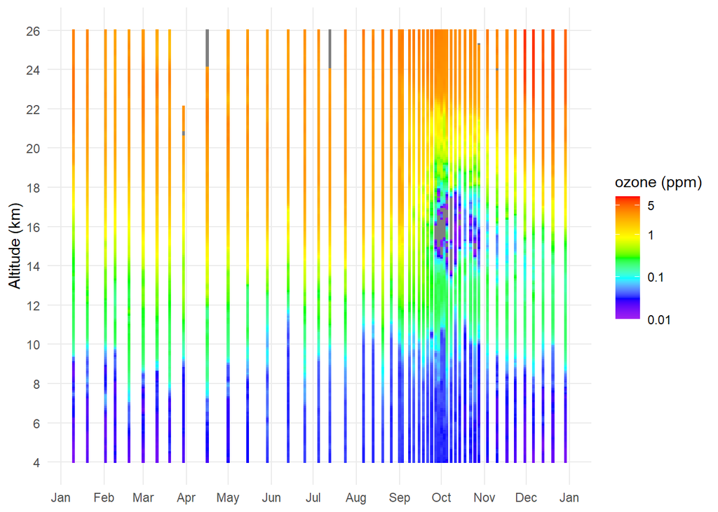

The choice of nearest neighbors was based on these considerations:

- Since there were few predictors, distance calculations between neighbors were likely to accurately reveal close relationships.
- The launches occur with regularity throughout the year, so for most or all estimates, there were likely to be near neighbors.
- Intuitively, for visualization purposes, it seemed to be a simple, straightforward, and potentially effective approach.

#### Predictors

Minimal predictors were chosen and the choices were based on these considerations:

- Year: Important to associate observations that were nearby in time. Also important because of gradual ozone recovery, which is a long-term gradual shift brought about by the expiration of the CFCs that cause ozone layer destruction
- Julian date: Also necessary to identify nearby ozonesonde observations. Also reveals seasonality of the ozone hole.
- Altitude: A first-order estimate of ozone concentration, as the atmosphere has a stratified structure and the ozone layer is known to occur at a certain altitude range.

#### Hyperparameter tuning

To tune the $K$ neighbors hypermarameter, the training set was cross validated using five folds, stratified by the response variable (ppmv ozone). $K=3$ was chosen based on best mean RMSE.

## Results

**Recreated plot**

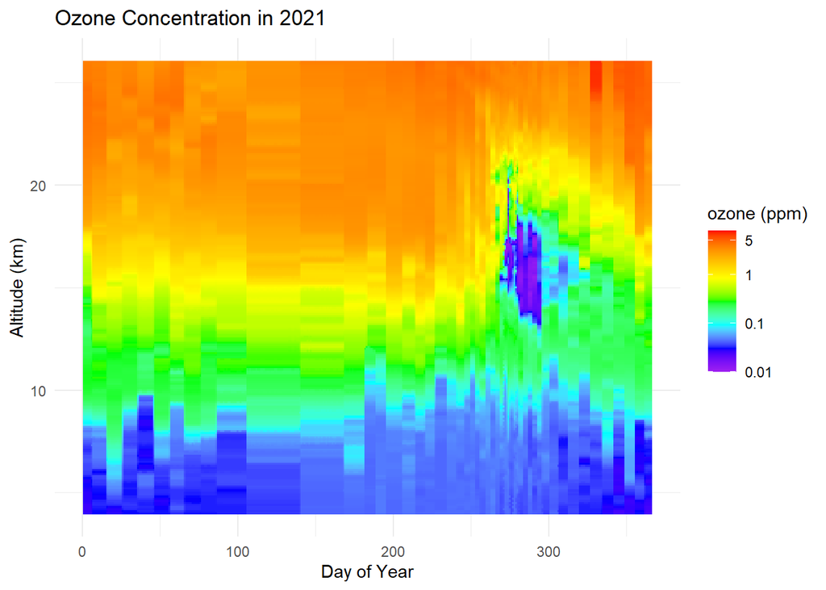

**Original plot**

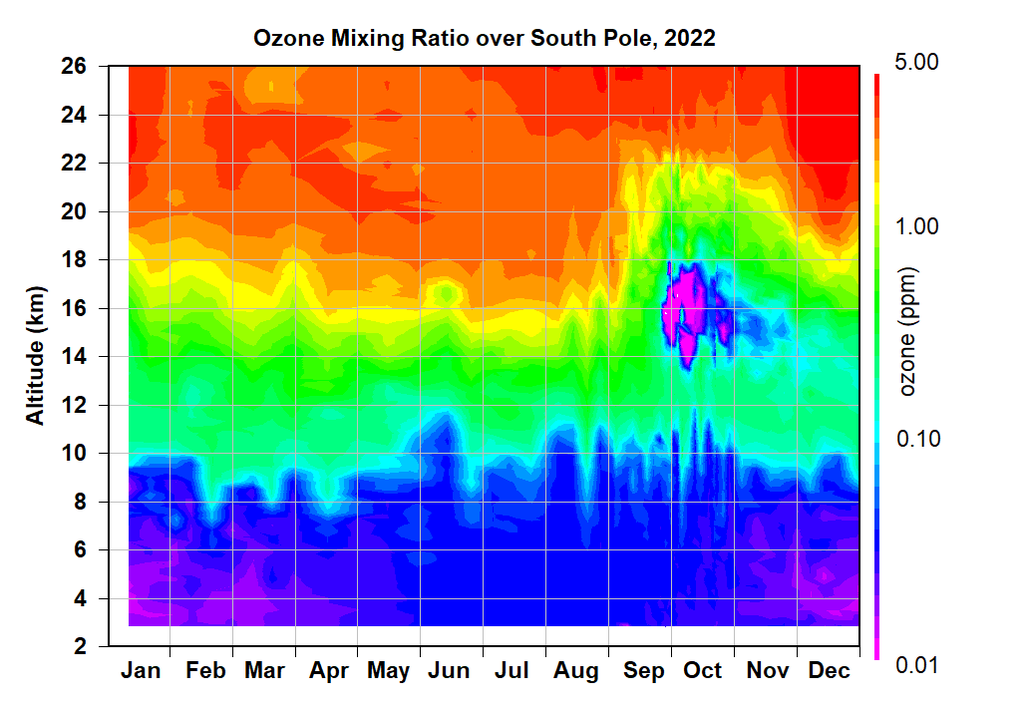

ozone 2022

## Discussion

The reproduction does however have a “grainier” appearance than the original. In places where there are fewer profiles, the pixelation or grainy effect is more pronounced.

## References

Read more about the fascinating science behind the formation of the ozone hole [here.](https://gml.noaa.gov/dv/spo_oz/)

Read more about the pollutants that cause the ozone hole – and the global effort to reduce them in order to reverse the destruction of the ozone layer – [here.](https://gml.noaa.gov/hats/about/cfc.html)

For detailed instructions on how to prepare and launch an ozonesonde, [check out the manual and videos given by Patrick Cullis.](https://patrickcullis.com/ozonesonde-instructions.html)